# E-News Express

## Question 1 : Define the problem and perform an EDA

## Description

### Background:

An online news portal aims to expand its business by acquiring new subscribers. Every visitor to the website takes certain actions based on their interest. The company plans to analyze these interests and wants to determine whether a new feature will be effective or not. Companies often analyze users' responses to two variants of a product to decide which of the two variants is more effective. This experimental technique is known as a/b testing that is used to determine whether a new feature attracts users based on a chosen metric.

Suppose you are hired as a Data Scientist in E-news Express. The design team of the company has created a new landing page. You have been assigned the task to decide whether the new landing page is more effective to gather new subscribers. Suppose you randomly selected 100 users and divided them equally into two groups. The old landing page is served to the first group (control group) and the new landing page is served to the second group (treatment group). Various data about the customers in both groups are collected in 'abtest.csv'. Perform the statistical analysis to answer the following questions using the collected data.

### Objective:

The main objective is to determine whether the new landing page is more effective at attracting new subscribers than the old landing page. This will be done by:

1) Performing statistical analysis of the business data.

2) Exploring the dataset and extracting insights from the data with the key objective in mind.

### Statistical analysis will be performed to answer the following questions:

1. Explore the dataset and extract insights using Exploratory Data Analysis.
2. Do the users spend more time on the new landing page than the old landing page?
3. Is the conversion rate (the proportion of users who visit the landing page and get converted) for the new page greater than the conversion rate for the old page?
4. Does the converted status depend on the preferred language? [Hint: Create a contingency table using the pandas.crosstab() function]
5. Is the mean time spent on the new page same for the different language users?

*Consider a significance level of 0.05 for all tests.

Data Dictionary:

- user_id - This represents the user ID of the person visiting the website.
- group - This represents whether the user belongs to the first group (control) or the second group (treatment).
- landing_page - This represents whether the landing page is new or old.
- time_spent_on_the_page - This represents the time (in minutes) spent by the user on the landing page.
- converted - This represents whether the user gets converted to a subscriber of the news portal or not.
- language_preferred - This represents the language chosen by the user to view the landing page.

### Importing the necessary libraries

```python
import numpy as np
import pandas as pd
import seaborn as sns
import scipy.stats as stats
from scipy.stats import norm
import matplotlib.pyplot as plt
```

### Reading the data into a dataframe

```python
df = pd.read_csv('abtest.csv')
df.head()
```

|  | user_id | group | landing_page | time_spent_on_the_page | converted | language_preferred |
| --- | --- | --- | --- | --- | --- | --- |
| 0 | 546592 | control | old | 3.48 | no | Spanish |
| 1 | 546468 | treatment | new | 7.13 | yes | English |
| 2 | 546462 | treatment | new | 4.40 | no | Spanish |
| 3 | 546567 | control | old | 3.02 | no | French |
| 4 | 546459 | treatment | new | 4.75 | yes | Spanish |

### Understanding the structure of the data

```python
# shape of the dataset
df.shape
```

```
(100, 6)
```

The dataset contains 100 rows and 6 columns

```python
# information about the columns in the dataset
df.info()
```

```
<class 'pandas.core.frame.DataFrame'>
RangeIndex: 100 entries, 0 to 99
Data columns (total 6 columns):
 #   Column                  Non-Null Count  Dtype
---  ------                  --------------  -----
 0   user_id                 100 non-null    int64
 1   group                   100 non-null    object
 2   landing_page            100 non-null    object
 3   time_spent_on_the_page  100 non-null    float64
 4   converted               100 non-null    object
 5   language_preferred      100 non-null    object
dtypes: float64(1), int64(1), object(4)
memory usage: 4.8+ KB
```

The `group`,`landing_page`,`converted` and `language_preferred` columns are objects. While, user_id and time_spent_on_the_page are numerical.

```python
# coverting "objects" to "category" reduces the data space required to store the dataframe
# write the code to convert 'landing_page', 'converted' and 'language_preferred' into categorical data

df.landing_page = df.landing_page.astype('category')
df.converted = df.converted.astype('category')
df.language_preferred = df.language_preferred.astype('category')

# use info() to print a concise summary of the DataFrame
df.info()
```

```
<class 'pandas.core.frame.DataFrame'>
RangeIndex: 100 entries, 0 to 99
Data columns (total 6 columns):
 #   Column                  Non-Null Count  Dtype
---  ------                  --------------  -----
 0   user_id                 100 non-null    int64
 1   group                   100 non-null    object
 2   landing_page            100 non-null    category
 3   time_spent_on_the_page  100 non-null    float64
 4   converted               100 non-null    category
 5   language_preferred      100 non-null    category
dtypes: category(3), float64(1), int64(1), object(1)
memory usage: 3.1+ KB
```

The `landing_page`,`converted`and `language_preferred` columns are now categorical. `group` was left as object, due to issues with a box plot. While, `user_id` and `time_spent_on_the_page` are numerical.

```python
# distinct values of group
df.group.value_counts()
```

```
treatment    50
control      50
Name: group, dtype: int64
```

As mentioned in the background information, the sample of 100 people is split equally into two groups the `control` and `treatment`

```python
# distinct values of language_preferred
df.language_preferred.value_counts()
```

```
French     34
Spanish    34
English    32
Name: language_preferred, dtype: int64
```

Three languages are spoken with 34 people speaking `Spanish`, 34 people speaking `French` and 32 people speaking `English`.

```python
# checking for null or missing values
df.isnull().sum()
```

```
user_id                   0
group                     0
landing_page              0
time_spent_on_the_page    0
converted                 0
language_preferred        0
dtype: int64
```

There are no null or missing values in the data set

```python
df.describe(include ='all')
```

|  | user_id | group | landing_page | time_spent_on_the_page | converted | language_preferred |
| --- | --- | --- | --- | --- | --- | --- |
| count | 100.000000 | 100 | 100 | 100.000000 | 100 | 100 |
| unique | NaN | 2 | 2 | NaN | 2 | 3 |
| top | NaN | treatment | new | NaN | yes | French |
| freq | NaN | 50 | 50 | NaN | 54 | 34 |
| mean | 546517.000000 | NaN | NaN | 5.377800 | NaN | NaN |
| std | 52.295779 | NaN | NaN | 2.378166 | NaN | NaN |
| min | 546443.000000 | NaN | NaN | 0.190000 | NaN | NaN |
| 25% | 546467.750000 | NaN | NaN | 3.880000 | NaN | NaN |
| 50% | 546492.500000 | NaN | NaN | 5.415000 | NaN | NaN |
| 75% | 546567.250000 | NaN | NaN | 7.022500 | NaN | NaN |
| max | 546592.000000 | NaN | NaN | 10.710000 | NaN | NaN |

From the analysis we can see that the average time spent by the 100 users on both pages is 5.37 minutes with a max reading time of 10.7 minutes.A more useful analysis will be obtained when we describe the data as it exist in the two groups `control` and `treatment`.

## Exploratory Data Analysis (EDA)

## Explore all the variables and perform Univariate and Bivariate Analyses

```python
# function to plot a boxplot and a histogram along the same scale.

def histogram_boxplot(data, feature, figsize=(12, 7), kde=False, bins=None):
    """
    Boxplot and histogram combined

    data: dataframe
    feature: dataframe column
    figsize: size of figure (default (12,7))
    kde: whether to show the density curve (default False)
    bins: number of bins for histogram (default None)
    """
    f2, (ax_box2, ax_hist2) = plt.subplots(
        nrows=2,  # Number of rows of the subplot grid= 2
        sharex=True,  # x-axis will be shared among all subplots
        gridspec_kw={"height_ratios": (0.25, 0.75)},
        figsize=figsize,
    )  # creating the 2 subplots
    sns.boxplot(
        data=data, x=feature, ax=ax_box2, showmeans=True, color="violet"
    )  # boxplot will be created and a star will indicate the mean value of the column
    sns.histplot(
        data=data, x=feature, kde=kde, ax=ax_hist2, bins=bins, palette="winter"
    ) if bins else sns.histplot(
        data=data, x=feature, kde=kde, ax=ax_hist2
    )  # For histogram
    ax_hist2.axvline(
        data[feature].mean(), color="green", linestyle="--"
    )  # Add mean to the histogram
    ax_hist2.axvline(
        data[feature].median(), color="black", linestyle="-"
    )  # Add median to the histogram
```

```python
# function to create labeled barplots


def labeled_barplot(data, feature, perc=False, n=None):
    """
    Barplot with percentage at the top

    data: dataframe
    feature: dataframe column
    perc: whether to display percentages instead of count (default is False)
    n: displays the top n category levels (default is None, i.e., display all levels)
    """

    total = len(data[feature])  # length of the column
    count = data[feature].nunique()
    if n is None:
        plt.figure(figsize=(count + 1, 5))
    else:
        plt.figure(figsize=(n + 1, 5))

    plt.xticks(rotation=90, fontsize=15)
    ax = sns.countplot(
        data=data,
        x=feature,
        palette="Paired",
        order=data[feature].value_counts().index[:n].sort_values(),
    )

    for p in ax.patches:
        if perc == True:
            label = "{:.1f}%".format(
                100 * p.get_height() / total
            )  # percentage of each class of the category
        else:
            label = p.get_height()  # count of each level of the category

        x = p.get_x() + p.get_width() / 2  # width of the plot
        y = p.get_height()  # height of the plot

        ax.annotate(
            label,
            (x, y),
            ha="center",
            va="center",
            size=12,
            xytext=(0, 5),
            textcoords="offset points",
        )  # annotate the percentage

    plt.show()  # show the plot
```

### Analysis of the 100 users in the database (i.e both landing pages)

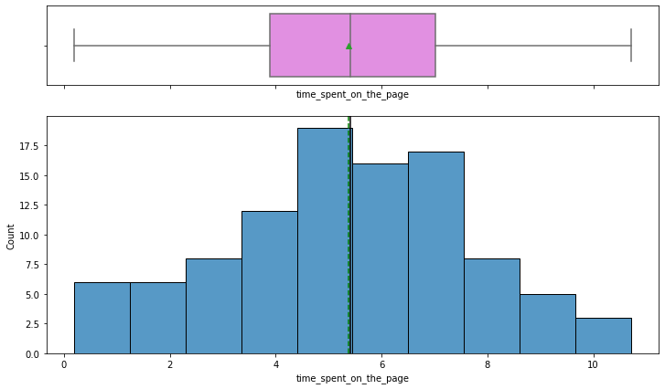

```python
## This code generates a box plot of the 100 users in the analyses (both old and new landing pages)
histogram_boxplot(df, 'time_spent_on_the_page', bins = 10 )
```

```python
df.mean()
```

```
user_id                   546517.0000
time_spent_on_the_page         5.3778
dtype: float64
```

#### Observations

- The box plot of the 100 users indicates that the time spent on both the old and new landing pages follow a normal distribution
- The mean of the time spent `5.377` is almost equal to the median value of `5.42`.

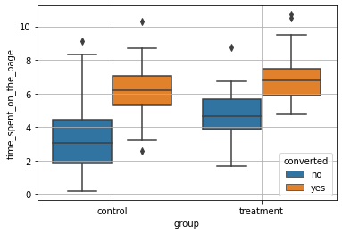

```python
# visual analysis of the time spent by control group and treatment groups on old and new landing pages
# the plots have been legend by those that are converted to subscribers or not
sns.boxplot(x="group", y="time_spent_on_the_page", data = df, hue = "converted")
plt.grid()
plt.show()
```

#### Observations

- The means of the converted (subscribers) of both the old and new landing pages are higher than the non converted
- There appears to be outliers in all of the groups
- The control group refers to the sample group on the old landing page
- The treatment group refers to the sample group on the new landing page
- In the control group the mean time spent by the converted (subscribers) appears to be less than that of the converted in the control group. This will have to be further explored with `hypothesis` testing.

## Splitting the data into the various groups `control` and `treatment`

### Control Group Analysis

This group contains the 50 users on the old landing page. Here we we take a look at the descriptive statistics of variables such as 1) Time spent on the page

2) Proportion of users that have converted to subscribers

3) Language spoken by the users on the old page

```python
## This code creates a data frame with only users of the old landing page
control = df.loc[df['group'].str.contains("control")]
control
```

|  | user_id | group | landing_page | time_spent_on_the_page | converted | language_preferred |
| --- | --- | --- | --- | --- | --- | --- |
| 0 | 546592 | control | old | 3.48 | no | Spanish |
| 3 | 546567 | control | old | 3.02 | no | French |
| 5 | 546558 | control | old | 5.28 | yes | English |
| 7 | 546581 | control | old | 6.53 | yes | Spanish |
| 9 | 546548 | control | old | 2.08 | no | English |
| 10 | 546588 | control | old | 6.21 | yes | Spanish |
| 11 | 546546 | control | old | 2.58 | yes | English |
| 14 | 546578 | control | old | 8.72 | yes | Spanish |
| 17 | 546555 | control | old | 0.40 | no | English |
| 18 | 546493 | control | old | 10.30 | yes | English |
| 19 | 546549 | control | old | 3.88 | yes | English |
| 20 | 546560 | control | old | 2.66 | no | French |
| 21 | 546584 | control | old | 7.03 | yes | Spanish |
| 27 | 546586 | control | old | 4.05 | no | Spanish |
| 29 | 546575 | control | old | 4.28 | no | French |
| 31 | 546556 | control | old | 3.52 | yes | English |
| 32 | 546585 | control | old | 5.39 | yes | Spanish |
| 33 | 546577 | control | old | 4.52 | no | Spanish |
| 34 | 546587 | control | old | 4.46 | no | Spanish |
| 35 | 546552 | control | old | 8.50 | yes | English |
| 36 | 546551 | control | old | 3.13 | no | English |
| 37 | 546557 | control | old | 6.04 | yes | English |
| 39 | 546589 | control | old | 0.19 | no | Spanish |
| 40 | 546559 | control | old | 8.46 | yes | French |
| 41 | 546570 | control | old | 1.92 | no | French |
| 45 | 546565 | control | old | 8.02 | no | French |
| 50 | 546554 | control | old | 0.22 | no | English |
| 53 | 546576 | control | old | 4.71 | no | Spanish |
| 55 | 546563 | control | old | 0.93 | no | French |
| 56 | 546569 | control | old | 1.81 | no | French |
| 58 | 546562 | control | old | 7.40 | yes | French |
| 59 | 546574 | control | old | 9.15 | no | French |
| 62 | 546572 | control | old | 4.18 | no | French |
| 63 | 546590 | control | old | 5.47 | no | Spanish |
| 64 | 546553 | control | old | 5.96 | yes | English |
| 66 | 546545 | control | old | 6.60 | yes | English |
| 67 | 546582 | control | old | 4.75 | yes | Spanish |
| 69 | 546579 | control | old | 2.23 | no | Spanish |
| 70 | 546568 | control | old | 0.40 | no | French |
| 74 | 546591 | control | old | 4.87 | no | Spanish |
| 75 | 546583 | control | old | 6.57 | yes | Spanish |
| 76 | 546573 | control | old | 1.44 | no | French |
| 79 | 546547 | control | old | 3.21 | yes | English |
| 83 | 546580 | control | old | 2.90 | no | Spanish |
| 84 | 546571 | control | old | 4.30 | no | French |
| 85 | 546564 | control | old | 0.91 | no | French |
| 89 | 546561 | control | old | 6.04 | yes | French |
| 92 | 546566 | control | old | 8.35 | no | French |
| 94 | 546550 | control | old | 3.05 | no | English |
| 96 | 546544 | control | old | 6.52 | yes | English |

```python
## This code give the descriptive statistics of all the variables in the 'control' group
control.describe(include ='all')
```

|  | user_id | group | landing_page | time_spent_on_the_page | converted | language_preferred |
| --- | --- | --- | --- | --- | --- | --- |
| count | 50.00000 | 50 | 50 | 50.000000 | 50 | 50 |
| unique | NaN | 1 | 1 | NaN | 2 | 3 |
| top | NaN | control | old | NaN | no | French |
| freq | NaN | 50 | 50 | NaN | 29 | 17 |
| mean | 546566.50000 | NaN | NaN | 4.532400 | NaN | NaN |
| std | 17.67767 | NaN | NaN | 2.581975 | NaN | NaN |
| min | 546493.00000 | NaN | NaN | 0.190000 | NaN | NaN |
| 25% | 546555.25000 | NaN | NaN | 2.720000 | NaN | NaN |
| 50% | 546567.50000 | NaN | NaN | 4.380000 | NaN | NaN |
| 75% | 546579.75000 | NaN | NaN | 6.442500 | NaN | NaN |
| max | 546592.00000 | NaN | NaN | 10.300000 | NaN | NaN |

```python
## This code gives a breakdown of the languages spoken by the individuals in the ' control' group
control['language_preferred'].value_counts()
```

```
French     17
Spanish    17
English    16
Name: language_preferred, dtype: int64
```

```python
## This code gives the number of converted users in the control group
len(control[control.converted=='yes'])
```

```
21
```

```python
control['landing_page'].value_counts()
```

```
old    50
new     0
Name: landing_page, dtype: int64
```

```python
## This code calculates the total time spent by all users in the control group
round(control.time_spent_on_the_page.sum(),2)
```

```
226.62
```

```python
## This code calculates the time spent by the converted users in the control group
control[control.converted=='yes'].time_spent_on_the_page.sum()
```

```
129.49
```

```python
## This code calculates the time spent by non-converted users in the control group
control[control.converted =='no'].time_spent_on_the_page.sum()
```

```
97.13
```

```python
## This code calculates the mean time spent by the converted users in the control group
control[control.converted=='yes'].time_spent_on_the_page.mean()
```

```
6.1661904761904776
```

```python
## This code calculates the mean time spent by non-converted users in the control group
control[control.converted =='no'].time_spent_on_the_page.mean()
```

```
3.3493103448275865
```

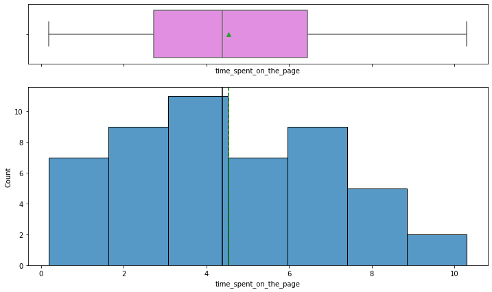

```python
## This code generates a box plot of time spent on the old landing page by users in the control group.
histogram_boxplot(control, 'time_spent_on_the_page' )
```

#### Observation

- From the box plot, in the control group of 50 people, the data appears to be right skewed.
- The mean time spent on the page is 4.53 mins with a median time of 4.38 minutes

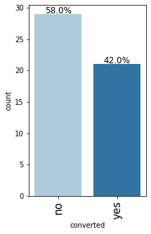

```python
## This barplot shows the converted vs non converted users in the control sample group
labeled_barplot(control, 'converted', perc=True)
```

#### Observation

- From the graph we can see that in the `control` group only 42% of the users are converted
- We also observe that 58% of the users are not converted

#### Observation for Control Group

- The control group has 50 members of which 21 have been converted ~ 42% .
- The converted members spend 129.49 minutes on the page.
- The not converted members spend 97.13 minutes on the page
- The total time spent by the control group on the landing page is 226.6 minutes

From the observations of the 50 members each we saw the following

- The total time spent by the control group on the landing page is 226.6 minutes.
- The total time spent by the treatment group on the new landing page is 311.16 minutes

### Treatment Group Analysis

```python
treatment = df.loc[df['group'].str.contains("treatment")]
treatment
```

|  | user_id | group | landing_page | time_spent_on_the_page | converted | language_preferred |
| --- | --- | --- | --- | --- | --- | --- |
| 1 | 546468 | treatment | new | 7.13 | yes | English |
| 2 | 546462 | treatment | new | 4.40 | no | Spanish |
| 4 | 546459 | treatment | new | 4.75 | yes | Spanish |
| 6 | 546448 | treatment | new | 5.25 | yes | French |
| 8 | 546461 | treatment | new | 10.71 | yes | French |
| 12 | 546491 | treatment | new | 5.86 | yes | Spanish |
| 13 | 546478 | treatment | new | 6.03 | yes | French |
| 15 | 546466 | treatment | new | 6.27 | yes | Spanish |
| 16 | 546443 | treatment | new | 8.73 | no | English |
| 22 | 546450 | treatment | new | 3.65 | no | English |
| 23 | 546475 | treatment | new | 7.02 | yes | English |
| 24 | 546456 | treatment | new | 6.18 | no | Spanish |
| 25 | 546455 | treatment | new | 4.39 | no | English |
| 26 | 546469 | treatment | new | 9.49 | yes | English |
| 28 | 546471 | treatment | new | 7.81 | yes | French |
| 30 | 546464 | treatment | new | 5.41 | yes | English |
| 38 | 546487 | treatment | new | 1.65 | no | Spanish |
| 42 | 546489 | treatment | new | 7.16 | yes | Spanish |
| 43 | 546453 | treatment | new | 7.16 | yes | English |
| 44 | 546488 | treatment | new | 3.91 | no | English |
| 46 | 546460 | treatment | new | 5.37 | yes | French |
| 47 | 546458 | treatment | new | 7.23 | yes | Spanish |
| 48 | 546492 | treatment | new | 8.08 | yes | Spanish |
| 49 | 546473 | treatment | new | 10.50 | yes | English |
| 51 | 546457 | treatment | new | 5.65 | no | English |
| 52 | 546479 | treatment | new | 6.47 | yes | Spanish |
| 54 | 546482 | treatment | new | 6.41 | yes | Spanish |
| 57 | 546454 | treatment | new | 8.30 | yes | French |
| 60 | 546470 | treatment | new | 6.01 | yes | French |
| 61 | 546467 | treatment | new | 6.79 | yes | French |
| 65 | 546445 | treatment | new | 7.27 | yes | French |
| 68 | 546484 | treatment | new | 6.70 | no | Spanish |
| 71 | 546476 | treatment | new | 5.42 | yes | French |
| 72 | 546452 | treatment | new | 5.08 | yes | English |
| 73 | 546444 | treatment | new | 7.46 | yes | English |
| 77 | 546485 | treatment | new | 3.88 | no | Spanish |
| 78 | 546486 | treatment | new | 9.12 | yes | French |
| 80 | 546490 | treatment | new | 4.68 | no | French |
| 81 | 546449 | treatment | new | 5.26 | yes | French |
| 82 | 546463 | treatment | new | 5.74 | yes | Spanish |
| 86 | 546465 | treatment | new | 6.71 | no | English |
| 87 | 546480 | treatment | new | 3.68 | no | French |
| 88 | 546447 | treatment | new | 3.30 | no | French |
| 90 | 546477 | treatment | new | 5.40 | no | French |
| 91 | 546451 | treatment | new | 8.47 | yes | English |
| 93 | 546474 | treatment | new | 4.94 | no | French |
| 95 | 546446 | treatment | new | 5.15 | no | Spanish |
| 97 | 546472 | treatment | new | 7.07 | yes | Spanish |
| 98 | 546481 | treatment | new | 6.20 | yes | Spanish |
| 99 | 546483 | treatment | new | 5.86 | yes | English |

```python
treatment.describe(include = 'all')
```

|  | user_id | group | landing_page | time_spent_on_the_page | converted | language_preferred |
| --- | --- | --- | --- | --- | --- | --- |
| count | 50.00000 | 50 | 50 | 50.000000 | 50 | 50 |
| unique | NaN | 1 | 1 | NaN | 2 | 3 |
| top | NaN | treatment | new | NaN | yes | French |
| freq | NaN | 50 | 50 | NaN | 33 | 17 |
| mean | 546467.50000 | NaN | NaN | 6.223200 | NaN | NaN |
| std | 14.57738 | NaN | NaN | 1.817031 | NaN | NaN |
| min | 546443.00000 | NaN | NaN | 1.650000 | NaN | NaN |
| 25% | 546455.25000 | NaN | NaN | 5.175000 | NaN | NaN |
| 50% | 546467.50000 | NaN | NaN | 6.105000 | NaN | NaN |
| 75% | 546479.75000 | NaN | NaN | 7.160000 | NaN | NaN |
| max | 546492.00000 | NaN | NaN | 10.710000 | NaN | NaN |

```python
treatment['language_preferred'].value_counts()
```

```
French     17
Spanish    17
English    16
Name: language_preferred, dtype: int64
```

```python
len(treatment[treatment.converted=='yes'])
```

```
33
```

```python
treatment['landing_page'].value_counts()
```

```
new    50
old     0
Name: landing_page, dtype: int64
```

```python
## This code calculates the total time spent by all users in the treatment group
treatment.time_spent_on_the_page.sum()
```

```
311.16
```

```python
## This code calculates the time spent by the converted users in the treatment group
round(treatment[treatment.converted=='yes'].time_spent_on_the_page.sum(),2)
```

```
228.16
```

```python
## This code calculates the time spent by non-converted users in the control group
round(treatment[treatment.converted=='no'].time_spent_on_the_page.sum(),2)
```

```
83.0
```

```python
## This code calculates the mean time spent by the converted users in the treatment group
round(treatment[treatment.converted=='yes'].time_spent_on_the_page.mean(),2)
```

```
6.91
```

```python
## This code calculates the mean time spent by non-converted users in the control group
round(treatment[treatment.converted=='no'].time_spent_on_the_page.mean(),2)
```

```
4.88
```

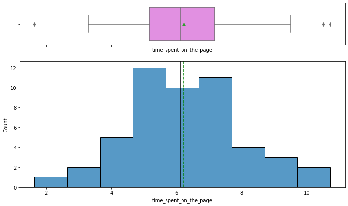

```python
## This code generates a box plot of time spent on the old landing page by users in the treatment group.
histogram_boxplot(treatment, 'time_spent_on_the_page' )
```

#### Observation

- From the box plot, in the treatment group of 50 people, the data appears to be non-skewed.
- The mean time spent on the page is 6.22 mins with a median time of 6.10 minutes

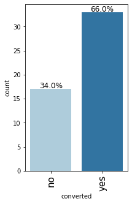

```python
labeled_barplot(treatment, 'converted', perc=True)
```

#### Observation for Treatment Group

- The treatment group has 50 members of which 33 have been converted ~ 66%
- The converted members spend 228.16 minutes on the page.
- The not converted members spend 83 minutes on the page
- The total time spent by the treatment group on the new landing page is 311.16 minutes

## Question 2: Insights from EDA

•The box plot of the 100 users indicates that the time spent on both the old and new landing pages follow a normal distribution.

•For the 100 users in aggregate, the mean of the time spent 5.377 on both landing pages is almost equal to the median value of 5.42.

•In the control group the mean time spent by the converted (subscribers) appears to be less than that of the converted in the treatment group. This will have to be further explored with hypothesis testing.

•From the histogram box plot of the control group of 50 people, the data appears to be right skewed. The mean time spent on the page is 4.53 mins with a median time of 4.38 minutes.

•From the histogram box plot of the treatment group of 50 people, the data appears to be non-skewed. The mean time spent on the page is 6.22 mins with a median time of 6.10 minutes.

•From the labelled bar plot we can see that in the `control` group only 42% of the users are converted. We also observe that 58% of the users are not converted.

•From the labelled bar plot we can see that in the `treatment` group 66% of the users are converted. We also observe that 34% of the users are not converted.

## Question 3: Do the users spend more time on the new landing page than the old landing page?

From the observations of the 50 members each in the `control` and `treatment` groups we saw the following

- The mean time spent by the `control` group on the landing page is 4.53 minutes.
- The mean time spent by the `treatment` group on the new landing page is 6.22 minutes

It would appear that more time is spent on the new landing page vs the old landing page, however we can test this by using `Hypothesis Testing`

Assuming that the times spent on the respective pages for both populations are normally distributed as determined by the Univariate Histplot Analyses above, do we have enough statistical evidence for this at the 5% significance level?

### Let's write the null and alternative hypothesis

Let $\mu_1, \mu_2$ be the mean time spent of **Treatment** and **Control** groups respectively.

We will test the null hypothesis

> $H_0:\mu_1=\mu_2$

against the alternate hypothesis

> $H_a:\mu_1>\mu_2$

### Let's have a look on the sample data

```python
treatment.head()
```

|  | user_id | group | landing_page | time_spent_on_the_page | converted | language_preferred |
| --- | --- | --- | --- | --- | --- | --- |
| 1 | 546468 | treatment | new | 7.13 | yes | English |
| 2 | 546462 | treatment | new | 4.40 | no | Spanish |
| 4 | 546459 | treatment | new | 4.75 | yes | Spanish |
| 6 | 546448 | treatment | new | 5.25 | yes | French |
| 8 | 546461 | treatment | new | 10.71 | yes | French |

```python
control.head()
```

|  | user_id | group | landing_page | time_spent_on_the_page | converted | language_preferred |
| --- | --- | --- | --- | --- | --- | --- |
| 0 | 546592 | control | old | 3.48 | no | Spanish |
| 3 | 546567 | control | old | 3.02 | no | French |
| 5 | 546558 | control | old | 5.28 | yes | English |
| 7 | 546581 | control | old | 6.53 | yes | Spanish |
| 9 | 546548 | control | old | 2.08 | no | English |

```python
# find the sample means and sample standard deviations for the two samples
print('The mean time_spent_on_the_page for the treatment group is ' + str(treatment['time_spent_on_the_page'].mean()))
print('The mean time_spent_on_the_page for the control group is ' + str(round(control['time_spent_on_the_page'].mean(),2)))
print('The standard deviation of time_spent_on_the_page for the treatment group is ' + str(round(treatment['time_spent_on_the_page'].std(), 2)))
print('The standard deviation of time_spent_on_the_page for the control group is ' + str(round(control['time_spent_on_the_page'].std(), 2)))
```

```
The mean time_spent_on_the_page for the treatment group is 6.2232
The mean time_spent_on_the_page for the control group is 4.53
The standard deviation of time_spent_on_the_page for the treatment group is 1.82
The standard deviation of time_spent_on_the_page for the control group is 2.58
```

### Let's test whether the T-test assumptions are satisfied or not

- Continuous data - Yes, the time_spent_on_the_page is measured on a continuous scale.
- Normally distributed populations - Yes, we saw from the Histplots that the populations are normal.Plus sample size 50>30. According to Central Limit Theorem for the number of sample means > 30 the distribution approaches normal distribution
- Independent populations - As we are taking random samples for two different groups, the two samples are from two independent populations.
- Unequal population standard deviations - As the sample standard deviations are different, the population standard deviations may be assumed to be different.
- Random sampling from the population - Yes, we are informed that the collected sample a simple random sample.

As a result, We can use a `two sample T-test` for this problem.

### p-value determination

```python
#import the required functions
from scipy.stats import ttest_ind

# find the p-value
test_stat , p_value = ttest_ind(treatment['time_spent_on_the_page'], control['time_spent_on_the_page'], equal_var = False, alternative = 'greater')
print('The p-value is ', round(p_value,7))
```

```
The p-value is  0.0001392
```

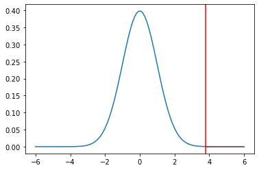

```python
# plotting the test statistic distribution along with computed test statistic
# We are plotting the distributions here to better visualize the calculations
x = np.linspace(-6, 6, 100) # create an array of 100 numbers starting from -6 and ending at 6
plt.plot(x, norm.pdf(x, 0, 1)) # plot the pdf of the normal distribution
plt.axvline(x = test_stat  , c = 'r') # draw a vertical red line through the mentioned point
x1 = np.linspace(test_stat , 6, 50) # create an array of 50 numbers starting from the test statistic and ending at 6
plt.fill_between(x1, norm.pdf(x1, 0, 1), color='r') # fill the area under the curve after the test statistic value with red color
plt.show() # display the plot
```

### Insight

As the p-value (~0.0001392) is less than the level of significance, we can reject the null hypothesis. Hence, we do have enough evidence to support the claim that users spend more time on the new landing page than on the old landing page.

## Question 4:Is the conversion rate (the proportion of users who visit the landing page and get converted) for the new page greater than the conversion rate for the old page?

Based on the analysis above, we observed the following

- The control group has 50 members of which 21 have been converted ~ 42% .
- The treatment group has 50 members of which 33 have been converted ~ 66%

It would appear that the treatment group has a higher conversion rate than the control group, however we can test this by using `Hypothesis Testing`

### Let's write the null and alternative hypothesis

Let $p_1,p_2$ be the proportions of conversions in the control group and treatment group respectively.

As the Data Scientist I will be testing the null hypothesis

> $H_0:p_1 =p_2$

against the alternate hypothesis

> $H_a:p_1 < p_2$

Based on the data we have,

- It's a binomially distributed population since a person is either converted on the relevant landing page or not
- The members were randomly chosen and split into two groups for the control page and the treatment (new page)
- Can the binomial distribution be approximated to the normal distribution? We will have to check to see if np and n(1-p) are greater than or equal to 10.
- Here, n and p refer to the sample size and sample proportion respectively.

### For the Control Group

> $np_1 = 50\cdot \frac{21}{50} =21 \geq 10\\ n(1-p_1) = 50 \cdot \frac{50-21}{50} =29 \geq 10 $

### For the Treatment Group

> $np_2 = 50\cdot \frac{33}{50} =33 \geq 10\\ n(1-p_2) = 50 \cdot \frac{50-33}{50} =17 \geq 10 $

### Let's find the p-value using a proportions_ztest

```python
# import the required fuction
from statsmodels.stats.proportion import proportions_ztest

# set the counts of converted members
converted_members = np.array([21, 33])

# set the sample sizes
groups = np.array([50, 50])

# find the p-value
test_stat1, p_value = proportions_ztest(converted_members, groups, alternative = 'smaller')
print('The p-value is ' + str(round(p_value,5)))
```

```
The p-value is 0.00803
```

```python
test_stat1
```

```
-2.4077170617153842
```

### Compare the p-value with $\alpha$

```python
# print the conclusion based on p-value
if p_value < 0.05:
    print(f'As the p-value {round(p_value,5)} is less than the level of significance, we reject the null hypothesis.')
else:
    print(f'As the p-value {round(p_value,5)} is greater than the level of significance, we fail to reject the null hypothesis.')
```

```
As the p-value 0.00803 is less than the level of significance, we reject the null hypothesis.
```

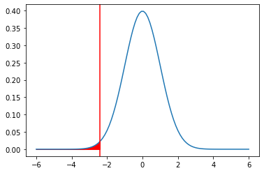

```python
# plotting the test statistic distribution along with computed test statistic
# We are plotting the distributions here to better visualize the calculations
x = np.linspace(-6, 6, 100) # create an array of 100 numbers starting from -6 and ending at 6
plt.plot(x, norm.pdf(x, 0, 1)) # plot the pdf of the normal distribution
plt.axvline(x = test_stat1  , c = 'r') # draw a vertical red line through the mentioned point
x1 = np.linspace(test_stat1 , -6, 50) # create an array of 50 numbers starting from the test statistic and ending at -6
plt.fill_between(x1, norm.pdf(x1, 0, 1), color='r') # fill the area under the curve after the test statistic value with red color
plt.show() # display the plot
```

### Insight

As the p-value is smaller than the significance level 0.05, we can reject the null hypothesis. Thus, the management of E-News Express has enough statistical significance to conclude that the new landing page has a greater proportion of subcribers than the old landing page.

## Question 5: Does the converted status depend on the preferred language?

To perform this analysis between converted status and language preference, first we have to create a contingency table. This analysis will also look at dependencies between converted status and language preferred, regardless of the landing page `(old vs new)`.

```python
### Preparing the contingency table
cont_table= pd.crosstab(df['converted'],df['language_preferred'])
cont_table
```

| language_preferred converted | English | French | Spanish |
| --- | --- | --- | --- |
| no | 11 | 19 | 16 |
| yes | 21 | 15 | 18 |

Observation

- From the 2 x 3 contingency table we can see there are three languages spoken.
- Of the 32 people that speak English, (21/32) or `66%` are converted
- Of the 34 people that speak French, (15/34) or `44%` are converted
- Of the 34 people that speak Spanish , (18/34) or `53%` are converted

### Defining the null and alternative hypotheses

$H_0:$ Converted Status is independent of Language preference

$H_a:$ Converted Status is NOT independent of Language preference

### Select the Appropriate Test

The hypotheses can be tested using a Chi-square test of independence. Here we would be looking at the two categorical variables `Converted Status` and `Language preference`

### Decide the significance level

Here, we select $\alpha$ = 0.05

### Calculation of the p-value

```python
df=pd.read_csv('abtest.csv')
#import the required functions
from scipy.stats import chi2_contingency
#preparing the contingency table
cont_table= pd.crosstab(df['converted'],df['language_preferred'])
chi, p_val, dof, expected = chi2_contingency(cont_table)
print('The p-value is ', p_val)
```

```
The p-value is  0.21298887487543447
```

```python
## Here we see the degrees of freedom form the chi2_contingency table
## This is calculated by (rows -1)*(columns -1)
dof
```

```
2
```

[figure not shown]

```python
## This code is to generate the Chi2 distribution for the 2 x 3 contingency table
import numpy as np
import matplotlib.pyplot as plt
from scipy.stats import chi2

#x-axis ranges from 0 to 20 with .001 steps
x = np.arange(0, 20, 0.001)

#define multiple Chi-square distributions
plt.plot(x, chi2.pdf(x, df=4), label='df: 2')


plt.xlabel('Value')
plt.ylabel('Frequency')
plt.title('Chi-Square Distribution')

#add legend to plot
plt.legend()
```

Observation

### Comparison of the p-value with $\alpha$

```python
# print the conclusion based on p-value
if p_val < 0.05:
    print(f'As the p-value {round(p_val,5)} is less than the level of significance, we reject the null hypothesis.')
else:
    print(f'As the p-value {round(p_val,5)} is greater than the level of significance, we fail to reject the null hypothesis.')
```

```
As the p-value 0.21299 is greater than the level of significance, we fail to reject the null hypothesis.
```

### Insight

As the p- value 0.21299 is greater than the level of significance, we fail to reject the null hypothesis. As a result the converted status in both the control group (old landing page) and treatment group (new landing page) are independent of the language spoken by the individual reading the news page.

## Question 6 : Is the mean time spent on the new page same for the different language users?

From the observations of the 50 members each in the`treatment` groups we saw the following

- 16 spoke English
- 17 spoke Spanish
- 17 spoke French

We can let the mean time they spend on the new landing page be equal to $\mu_1 , \mu_2 , and \mu_3$ respectively. To test whether the mean times are same, we can test this by using `Hypothesis Testing`and determine if we have enough statistical evidence to supportor reject the null `Hypothesis` at the 5% significance level.

### Defining the null and alternative hypotheses

$H_0:$ The mean times of the three languages on the new landing page are equal : $\mu_1 = \mu_2 =\mu_3$

$H_a:$ The mean times of the three languages on the new landing page are different :$\mu_1 \neq \mu_2 \neq \mu_3$

```python
treatment.head()
```

|  | user_id | group | landing_page | time_spent_on_the_page | converted | language_preferred |
| --- | --- | --- | --- | --- | --- | --- |
| 1 | 546468 | treatment | new | 7.13 | yes | English |
| 2 | 546462 | treatment | new | 4.40 | no | Spanish |
| 4 | 546459 | treatment | new | 4.75 | yes | Spanish |
| 6 | 546448 | treatment | new | 5.25 | yes | French |
| 8 | 546461 | treatment | new | 10.71 | yes | French |

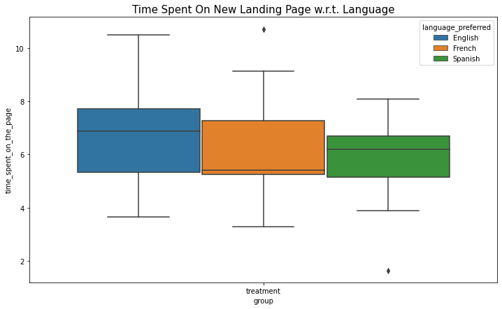

```python
# draw the boxplot for visualization
fig, ax = plt.subplots(figsize = (12,7))
a = sns.boxplot(x= 'group', y = 'time_spent_on_the_page',  hue = 'language_preferred', data = treatment)
a.set_title("Time Spent On New Landing Page w.r.t. Language", fontsize=15)
plt.show()
```

The box plot above shows the time spent on the new landing page by users speaking the three languages. It appears that the means are different. However to reject the null hypothesis that the means are the same, we can perform a `One Way ANOVA` test, once the conditions below are satisfied

### Shapiro-Wilk's test

We will test the null hypothesis

> $H_0:$ time spent on the page follows a normal distribution against

against the alternative hypothesis

> $H_a:$ time spent on the page does not follow a normal distribution

```python
# Assumption 1: Normality
# import the required function
from scipy import stats

# find the p-value
w, p_value = stats.shapiro(treatment['time_spent_on_the_page'])
print('The p-value is', p_value)
```

```
The p-value is 0.8040016293525696
```

Since p-value of the test is very large, we fail to reject the null hypothesis that the response follows the normal distribution.

### Levene’s test

We will test the null hypothesis

> $H_0$: All the population variances are equal

against the alternative hypothesis

> $H_a$: At least one variance is different from the rest

```python
#Assumption 2: Homogeneity of Variance
#import the required function
from scipy.stats import levene
statistic, p_value = levene( treatment['time_spent_on_the_page'][treatment['language_preferred']=="English"],
                                   treatment['time_spent_on_the_page'][treatment['language_preferred']=="Spanish"],
                                  treatment['time_spent_on_the_page'][treatment['language_preferred']=="French"])
# find the p-value
print('The p-value is', p_value)
```

```
The p-value is 0.46711357711340173
```

Since the p-value is large, we fail to reject the null hypothesis of homogeneity of variances

### Let's test again whether the assumptions are satisfied or not

- The populations are normally distributed - Yes, the normality assumption is verified using the Shapiro-Wilk’s test.
- Samples are independent simple random samples - Yes, we are informed that the collected sample is a simple random sample.
- Sample variances are equal - Yes, the homogeneity of variance assumption is verified using the Levene's test.

### Raw data preview

```python
## This code calculates the means of the time spent on the new landing page for English, French and Spanish users
a = treatment.loc[treatment['language_preferred'] == 'English', 'time_spent_on_the_page'].mean()
b = treatment.loc[treatment['language_preferred'] == 'Spanish', 'time_spent_on_the_page'].mean()
c = treatment.loc[treatment['language_preferred'] == 'French', 'time_spent_on_the_page'].mean()
print ('The means of time spent on page for English, Spanish and French in the treatment group are %1.3f'% a, '&', round(b,3),'&', round(c,3),'respectively')
```

```
The means of time spent on page for English, Spanish and French in the treatment group are 6.664 & 5.835 & 6.196 respectively
```

### Let's find the p-value

```python
#import the required function
from scipy.stats import f_oneway

# perform one-way anova test
test_stat, p_value = f_oneway(treatment.loc[treatment['language_preferred'] == 'English', 'time_spent_on_the_page'],
                              treatment.loc[treatment['language_preferred'] == 'Spanish', 'time_spent_on_the_page'],
                              treatment.loc[treatment['language_preferred'] == 'French', 'time_spent_on_the_page'])
print('The p-value is ' + str(p_value))
```

```
The p-value is 0.43204138694325955
```

Since p-value of the test is very large, we `fail to reject the null hypothesis`. This means that the mean times spent on the new landing page w.r.t to users that speak either of the three languages are equal. i.e : 𝜇1=𝜇2=𝜇3

### Conclusion

A study was conducted on 100 randomly selected users visiting the website E-news Express. The users were split equally into two groups with the old landing page was served to the first group (control group) and the new landing page was served to the second group (treatment group). Based on the analyses performed, these were the key finding.

1) A two sample T-Test was conducted to determine if users spent more time on the new landing page than the old landing page. Based on the p-value (~0.0001392), we rejected the null hypothesis and accepted the alternative which stated that users spent more time on the new landing page vs the old landing page.

3) A Chi-Squared test of independence was conducted to see if two categorical variables Converted Status and Language preference were independent or not. As the p- value 0.21299 is greater than the level of significance, we failed to reject the null hypothesis. As a result the converted status in both the control group (old landing page) and treatment group (new landing page) were independent of the language spoken by the individual reading the news page.

4) A One Way ANOVA test was conducted to see if the mean times of the three languages on the new landing page were equal. First the Shapiro-Wilk’s Test was conducted to confirm that the population followed a normal distribution, followed by the Levene’s test to confirm that the population variances were equal. For the One Way Anova test, since the p-value of the test was very large (0.432) , we failed to reject the null hypothesis. This means that the mean times spent on the new landing page w.r.t to users that speak either of the three languages were equal.